# Analisis de la actividad fisica

“Rosa Idalia Sánchez Hernández”

18 de marzo de 2016

Introduccion

Con el fin de reducir el riesgo de enfermedades se recomienda la activacion fisica aerobica, de intensidad moderada. Se desea conocer los habitos de una persona que no tiene mucho tiempo para ir al gimnasio, asi que se estudia la cantidad de pasos que da en intervalos de 5 minutos durante dos meses. Despues se desea comparar la esta actividad fisica entre semana y los fines de semana.

Para cargar los datos que se utilizaron, primero debemos fijar el directorio en donde se encuentran los datos, en este caso se guardaron en la variable activity.

```r
setwd("/Users/rosai/Documents/descargas lunes 14 marzo 2016/R markdown")
activity=read.csv("activity.csv")
```

En el siguiente cuadro podemos visualizar los datos tal como se registraron, la primer columna muestra el numero de pasos registrados, la segunda columna muestra la fecha en que se tomo la medicion y la tercer columna contiene un identificador del intervalo.

```r
print(activity)
```

[output not shown]

[output cut: 17554 more lines]

Procesamiento de los datos

Con la siguiente instruccion se desea conocer as informacion acerca de la cantidad de veces que se repite la fecha, y posterior a eso se observa que el numero de intervalos medidos por dia es el mismo de 288. Asi se decide reorganizar la informacion en una matriz de 288 filas y 61 columnas , cada columna son las mediciones tomadas en un dia diferente.

```r
info=table(activity[,2])
pasos=matrix(activity[,1], nrow=288 , ncol = 61, byrow = FALSE)
```

A continuacion se muestra la matriz con el reacomodo de los datos

```r
print(pasos)
```

[output not shown]

[output cut: 1719 more lines]

Con los datos ya reacomodados calculamos la media y la mediana de los datos por dia, con las siguientes instrucciones

```r
media=rep(0,61)
mediana=rep(0,61)
for (i in 1:61)
{media[i]=mean(pasos[,i])
mediana[i]=median(pasos[,i])}
print(media)
```

```
##  [1]         NA  0.4375000 39.4166667 42.0694444 46.1597222 53.5416667
##  [7] 38.2465278         NA 44.4826389 34.3750000 35.7777778 60.3541667
## [13] 43.1458333 52.4236111 35.2048611 52.3750000 46.7083333 34.9166667
## [19] 41.0729167 36.0937500 30.6284722 46.7361111 30.9652778 29.0104167
## [25]  8.6527778 23.5347222 35.1354167 39.7847222 17.4236111 34.0937500
## [31] 53.5208333         NA 36.8055556 36.7048611         NA 36.2465278
## [37] 28.9375000 44.7326389 11.1770833         NA         NA 43.7777778
## [43] 37.3784722 25.4722222         NA  0.1423611 18.8923611 49.7881944
## [49] 52.4652778 30.6979167 15.5277778 44.3993056 70.9270833 73.5902778
## [55] 50.2708333 41.0902778 38.7569444 47.3819444 35.3576389 24.4687500
## [61]         NA
```

```r
print(mediana)
```

```
##  [1] NA  0  0  0  0  0  0 NA  0  0  0  0  0  0  0  0  0  0  0  0  0  0  0
## [24]  0  0  0  0  0  0  0  0 NA  0  0 NA  0  0  0  0 NA NA  0  0  0 NA  0
## [47]  0  0  0  0  0  0  0  0  0  0  0  0  0  0 NA
```

Visualicemos la siguiente gráfica de barras en donde se muestra la media de la cantidad de pasos registrados por cada dia

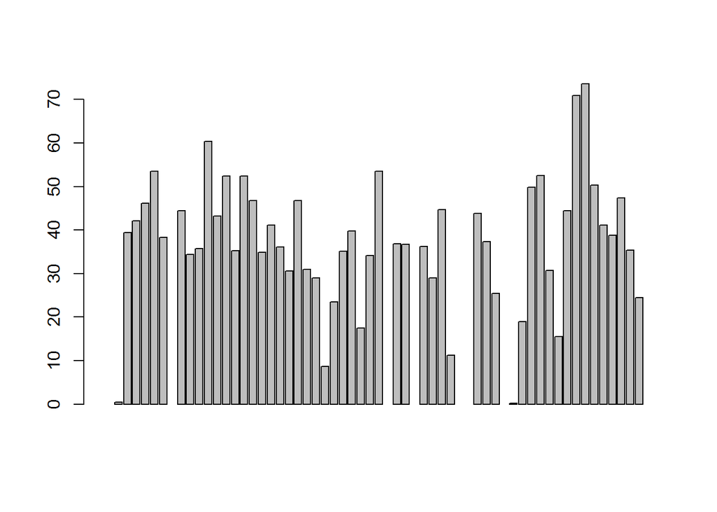

Se crearon una lista de los ìndices en que cambia la fecha para manipularlos de forma posterior

```r
dias=(1:61)
dias=dias*288;
```

Con la siguiente instruccion se reconoce el formato de la segunda columna de la matriz activity como fechas y con el comando weekdays se puede obtener el dia de la semana asociado a cada una de las fechas

```r
today<-as.Date(activity[dias,2])
dias2=weekdays(today, abbreviate = FALSE)
```

Se crean y se manipulan los siguientes arreglos para guardar las medias correspondientes a los fines de semana y los correspondientes a los dias entre semana

```r
findesem=rep(0,16)
entresem=rep(0,45)
k=1
j=1
for (i in 1:61)
{  if (dias2[i]=="sábado"|| dias2[i]=="domingo")
  {findesem[k]=media[i]
  k=k+1}
  else
  {entresem[j]=media[i]
  j=j+1}
}
```

A continuacion se grafican las medias entre semana y en fin de semana Medias del fin de semana

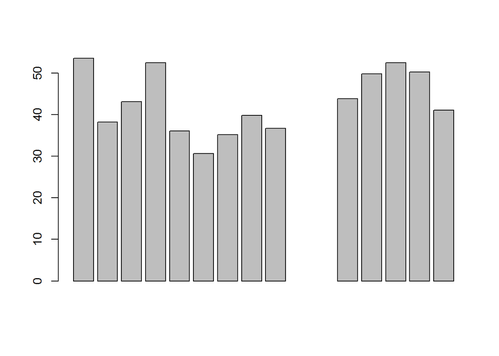

```r
barplot(findesem)
```

Medias de entre semana

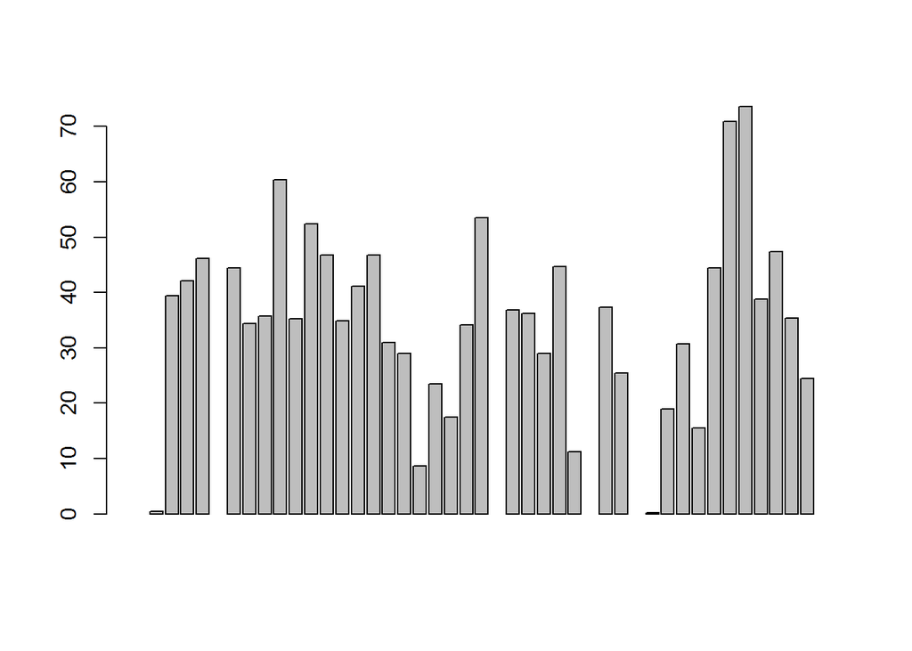

```r
barplot(entresem)
```

Para comparar las dos poblaciones se crea una prueba t-student con la finalidad de ver si hay diferencia una diferencia significativa entre la cantidad de pasos que se dan entre semana y en fin de semana con la siguiente intruccion

```r
t.test(entresem,findesem)
```

```
##
##  Welch Two Sample t-test
##
## data:  entresem and findesem
## t = -2.3552, df = 47.662, p-value = 0.02268
## alternative hypothesis: true difference in means is not equal to 0
## 95 percent confidence interval:
##  -14.34970  -1.13112
## sample estimates:
## mean of x mean of y
##  35.33796  43.07837
```